# Practical Machine Learning - Human Activities Recognition

Andy Majumdar

2 February 2019

```r
knitr::opts_chunk$set(echo = TRUE,warning=FALSE,fig.width=12,fig.align = "center",
                      fig.path = "README_figs/README-")
```

## Human Activities Research

Quality of execution is defined after investigating three aspects that pertain to qualitative activity recognition: the problem of specifying correct execution, the automatic and robust detection of execution mistakes, and how to provide feedback on the quality of execution to the user. Both on-body sensing approach and “ambient sensing approach” (by using Microsoft Kinect - dataset still unavailable) are used.

Six young health participants were asked to perform one set of 10 repetitions of the Unilateral Dumbbell Biceps Curl in five different fashions: * exactly according to the specification (Class A), * throwing the elbows to the front (Class B), * lifting the dumbbell only halfway (Class C), * lowering the dumbbell only halfway (Class D) and * throwing the hips to the front (Class E).

Class A corresponds to the specified execution of the exercise, while the other 4 classes correspond to common mistakes. Participants were supervised by an experienced weight lifter to make sure the execution complied to the manner they were supposed to simulate. The exercises were performed by six male participants aged between 20-28 years, with little weight lifting experience.

## Loading the datasets

The datasets are loaded from the given url given in the problems:

```r
trainUrl <- "http://d396qusza40orc.cloudfront.net/predmachlearn/pml-training.csv"
testUrl <- "http://d396qusza40orc.cloudfront.net/predmachlearn/pml-testing.csv"

training <- read.csv(url(trainUrl), na.strings=c("NA","#DIV/0!",""))
testing <- read.csv(url(testUrl), na.strings=c("NA","#DIV/0!",""))

cluster <- makeCluster(detectCores() - 1)
registerDoParallel(cluster)
```

## Create training and validation dataset and cleaning

70% of the training dataset is used for training model and rest for cross-validations.The accuracy of the cross validation is important to choose the model.

```r
inTrain <- createDataPartition(y=training$classe, p=0.7, list=FALSE)
myTraining <- training[inTrain, ]; myTesting <- training[-inTrain, ]
dim(myTraining); dim(myTesting)
```

```
## [1] 13737   160
```

```
## [1] 5885  160
```

160 variables can be way too many for us and first we are going to cleanup the data

We will run the dataset two identify redundant zero variables and reduce the number of variables. All classe and particpiants have sufficient observations inside them.

```r
nzvTraining <- nearZeroVar(myTraining, saveMetrics=TRUE)
trainingSub <- myTraining[,(nzvTraining$nzv==FALSE)&(nzvTraining$zeroVar==FALSE)]
ncol(trainingSub)
```

```
## [1] 130
```

Now the above is 130 variables after removing the zero variances and near zero variances. They have very few unique values relative to the number of samples and the ratio of the frequency of the most common value to the frequency of the second most common value is large. The first few columns like timestamp etc. are removed as they are not considered the influencing variables.

```r
trainingSub <- trainingSub[,7:length(colnames(trainingSub))]
```

Now remove variables with more than 20% NAs in their values.

```r
miss <- colSums(is.na(trainingSub))
miss_prec <- miss/nrow(trainingSub)*100
col_miss <- names(miss_prec[miss_prec>20])

trainingSub <- trainingSub[,!(names(trainingSub) %in% col_miss)]
keepCols <- colnames(trainingSub[, -53]) #remove classe as it's not contained in testing
testingSub <- myTesting[keepCols] #keep only variables in testing
dim(trainingSub); dim(testingSub) #trainingSub will have 1 more variable - classe
```

```
## [1] 13737    53
```

```
## [1] 5885   52
```

```r
any(colSums(is.na(trainingSub)>0) > 0)
```

```
## [1] FALSE
```

As evident that all the variables now in the training set, have 100% complete. There is no need for any imputing.Phew.

## Exploratory Data Analysis

Picked up some of the random variables and see how the distribution indicate about the influence on the class variable.

```
##
##    A    B    C    D    E
## 3906 2658 2396 2252 2525
```

```
##
##         A         B         C         D         E
## 0.2843416 0.1934920 0.1744195 0.1639368 0.1838101
```

```
##
##    adelmo  carlitos   charles    eurico    jeremy     pedro
## 0.2001165 0.1600786 0.1760210 0.1544733 0.1736915 0.1356191
```

```
##
##                    A         B         C         D         E
##   adelmo   0.2124936 0.2088036 0.2207846 0.1594139 0.1885149
##   carlitos 0.1495136 0.1809631 0.1439900 0.1540853 0.1750495
##   charles  0.1551459 0.1930023 0.1631886 0.1900533 0.1900990
##   eurico   0.1505376 0.1557562 0.1406511 0.1798401 0.1497030
##   jeremy   0.2158218 0.1271633 0.1848915 0.1616341 0.1576238
##   pedro    0.1164875 0.1343115 0.1464942 0.1549734 0.1390099
```

Adelmo & Jeremy seems to be doing better than others based on all the observations.All the classes have sufficient observations.

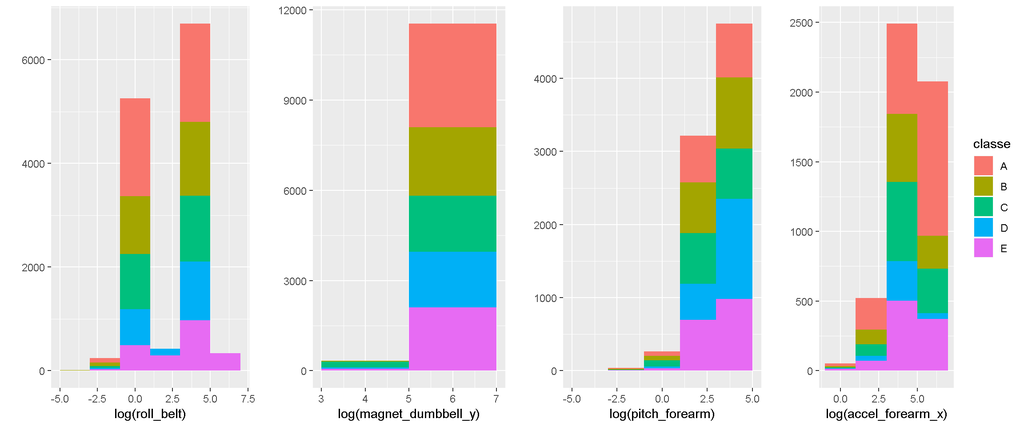

```r
p1 <- qplot(log(roll_belt), data = myTraining, binwidth=2, fill = classe, show.legend = FALSE)
p2 <- qplot(log(magnet_dumbbell_y), data = trainingSub, binwidth=2, fill = classe,show.legend = FALSE)
p3 <- qplot(log(pitch_forearm), data = trainingSub,binwidth=2,  fill = classe,show.legend = FALSE)
p4 <- qplot(log(accel_forearm_x), data = trainingSub, binwidth=2, fill = classe)

grid.arrange(p1, p2, p3, p4, nrow = 1)
```

## Principal Component Analysis

The PCA is useful to even help us doing the feature selection and provide an window for any preprocessing requirement in the subsequent steps where different models are selected.

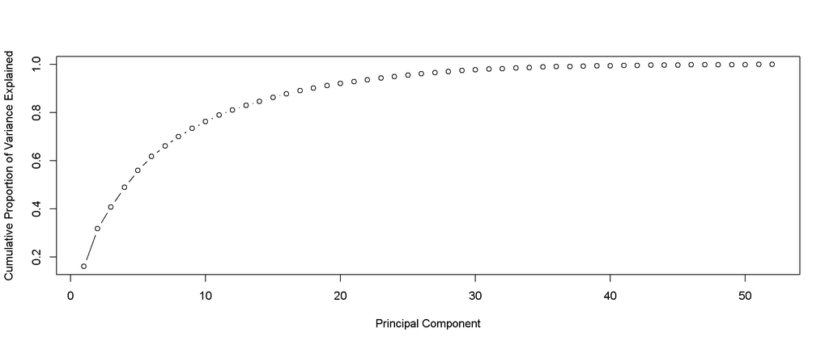

```r
prin_train <- prcomp(trainingSub[keepCols], scale. = T)
std_dev <- prin_train$sdev
pr_var <- std_dev^2
prop_varex <- pr_var/sum(pr_var)
# Simple plot b/w Principal Components and Variance.
plot(cumsum(prop_varex), xlab = "Principal Component",
     ylab = "Cumulative Proportion of Variance Explained", type = "b")
```

So around 15 variables explain the 80% of variance. For 90% variance 20-25 variables are useful. We can see if PCA should be included later. We can also use the recursive feature elimination to identify key features.

## Building Models

We will build 3 different models * Decision Tree * Stochastic Gradient Boosting * Random Forest

We expect to have more accuracy and less interpretability as we perform the modelling. We can also look into the key features.

### 1 Decision Tree

```r
system.time(model_dt <- rpart(classe ~ ., data = trainingSub, method="class"))
```

```
##    user  system elapsed
##    1.99    0.00    2.03
```

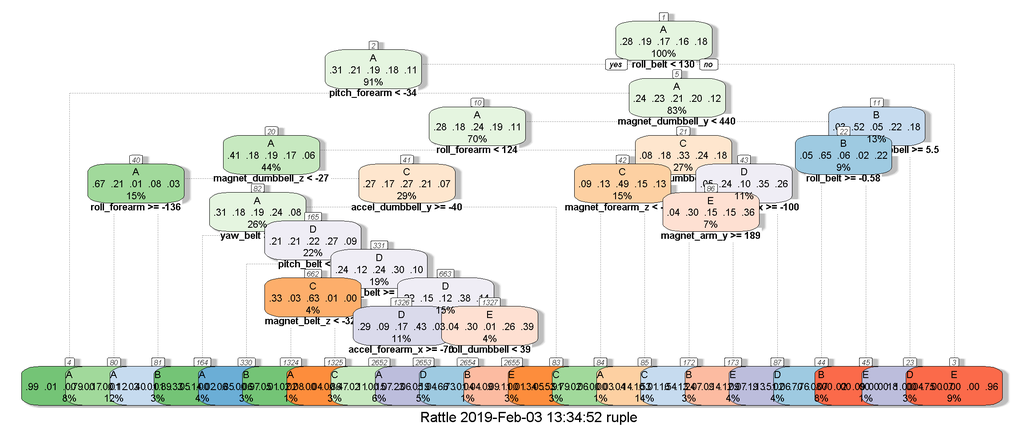

```r
fancyRpartPlot(model_dt, cex=0.7)   ##Graph 2
```

```r
prediction <- predict(model_dt, testingSub, type = "class")
confusionMatrix(prediction, myTesting$classe)
```

```
## Confusion Matrix and Statistics
##
##           Reference
## Prediction    A    B    C    D    E
##          A 1498  196   69  106   25
##          B   42  669   85   86   92
##          C   43  136  739  129  131
##          D   33   85   98  553   44
##          E   58   53   35   90  790
##
## Overall Statistics
##
##                Accuracy : 0.722
##                  95% CI : (0.7104, 0.7334)
##     No Information Rate : 0.2845
##     P-Value [Acc > NIR] : < 2.2e-16
##
##                   Kappa : 0.6467
##  Mcnemar's Test P-Value : < 2.2e-16
##
## Statistics by Class:
##
##                      Class: A Class: B Class: C Class: D Class: E
## Sensitivity            0.8949   0.5874   0.7203  0.57365   0.7301
## Specificity            0.9060   0.9357   0.9097  0.94717   0.9509
## Pos Pred Value         0.7909   0.6869   0.6273  0.68020   0.7700
## Neg Pred Value         0.9559   0.9043   0.9390  0.91897   0.9399
## Prevalence             0.2845   0.1935   0.1743  0.16381   0.1839
## Detection Rate         0.2545   0.1137   0.1256  0.09397   0.1342
## Detection Prevalence   0.3218   0.1655   0.2002  0.13815   0.1743
## Balanced Accuracy      0.9004   0.7615   0.8150  0.76041   0.8405
```

### 2 Stochasitic Gradient Boosting

```r
control <- trainControl(method = "repeatedcv", repeats = 3,verboseIter=FALSE, number=5, allowParallel = TRUE)
```

```r
system.time(model_gbm <- train(classe ~.,method="gbm",trControl = control,data=trainingSub,verbose = FALSE))
```

```
##    user  system elapsed
##   28.20    2.61 1057.19
```

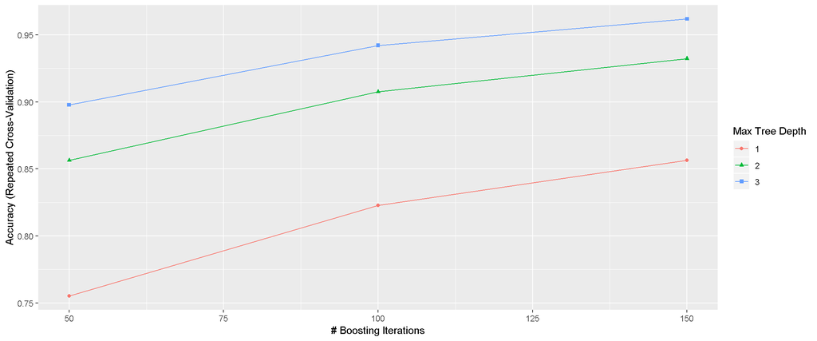

```r
ggplot(model_gbm)
```

```r
model_gbm$finalModel
```

```
## A gradient boosted model with multinomial loss function.
## 150 iterations were performed.
## There were 52 predictors of which 52 had non-zero influence.
```

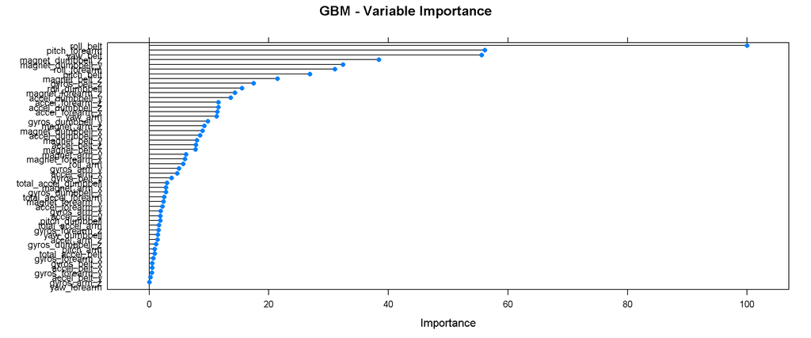

```r
plot(varImp(object=model_gbm),main="GBM - Variable Importance")
```

```r
prediction_gbm <- predict(model_gbm, testingSub, type = "raw")
confusionMatrix(prediction_gbm, myTesting$classe)
```

```
## Confusion Matrix and Statistics
##
##           Reference
## Prediction    A    B    C    D    E
##          A 1650   39    0    2    2
##          B   15 1066   39    3   20
##          C    5   31  968   35    5
##          D    4    3   17  918   21
##          E    0    0    2    6 1034
##
## Overall Statistics
##
##                Accuracy : 0.9577
##                  95% CI : (0.9522, 0.9627)
##     No Information Rate : 0.2845
##     P-Value [Acc > NIR] : < 2.2e-16
##
##                   Kappa : 0.9465
##  Mcnemar's Test P-Value : 3.028e-08
##
## Statistics by Class:
##
##                      Class: A Class: B Class: C Class: D Class: E
## Sensitivity            0.9857   0.9359   0.9435   0.9523   0.9556
## Specificity            0.9898   0.9838   0.9844   0.9909   0.9983
## Pos Pred Value         0.9746   0.9326   0.9272   0.9533   0.9923
## Neg Pred Value         0.9943   0.9846   0.9880   0.9907   0.9901
## Prevalence             0.2845   0.1935   0.1743   0.1638   0.1839
## Detection Rate         0.2804   0.1811   0.1645   0.1560   0.1757
## Detection Prevalence   0.2877   0.1942   0.1774   0.1636   0.1771
## Balanced Accuracy      0.9877   0.9598   0.9639   0.9716   0.9770
```

More than 95% accuracy - This is a great improvement over decision tree. But this takes a lot of time to complete and more than random forest below. XGBoost is a faster implementation of gbm but not included here. Also we have added provision for parallel processing which reduced the running time by 70% (YESSS!!)

### 3 Random Forest

Number of trees reduced to 100 to have faster running with 10 fold cross validations. Parallel processing is also allowed.

```r
control <- trainControl(method = "repeatedcv", repeats = 3,verboseIter=FALSE, number=10,search="random")
system.time(model_df <- train(classe ~.,method="rf",ntree = 100,data=trainingSub,trControl = control,verbose = FALSE,allowParallel = TRUE))
```

```
##    user  system elapsed
##   10.53    0.54  610.10
```

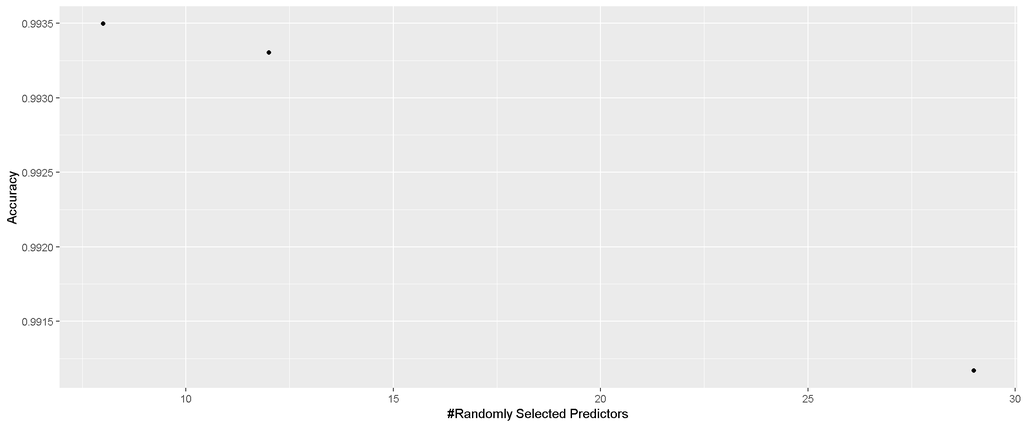

```r
ggplot(model_df)
```

```r
model_df$finalModel
```

```
##
## Call:
##  randomForest(x = x, y = y, ntree = 100, mtry = param$mtry, verbose = FALSE,      allowParallel = TRUE)
##                Type of random forest: classification
##                      Number of trees: 100
## No. of variables tried at each split: 8
##
##         OOB estimate of  error rate: 0.61%
## Confusion matrix:
##      A    B    C    D    E  class.error
## A 3903    1    1    0    1 0.0007680492
## B   17 2634    7    0    0 0.0090293454
## C    0   14 2376    6    0 0.0083472454
## D    0    0   26 2223    3 0.0128774423
## E    0    0    4    4 2517 0.0031683168
```

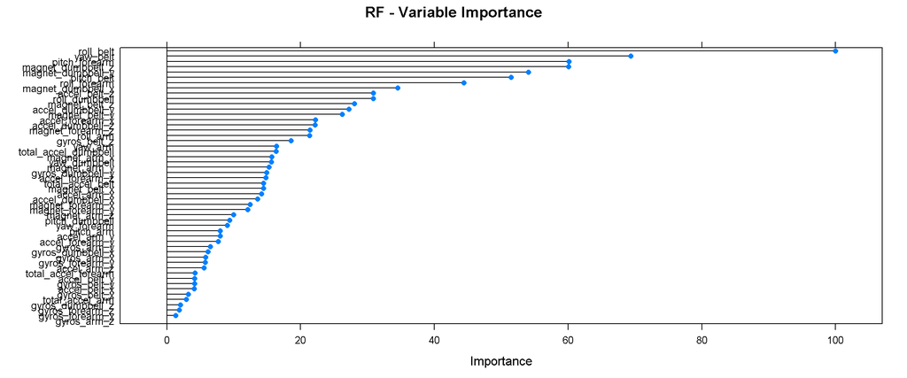

```r
plot(varImp(object=model_df),main="RF - Variable Importance")
```

```r
prediction_df <- predict(model_df, testingSub, type = "raw")
confusionMatrix(prediction_df, myTesting$classe)
```

```
## Confusion Matrix and Statistics
##
##           Reference
## Prediction    A    B    C    D    E
##          A 1673    7    0    0    0
##          B    1 1127   11    0    0
##          C    0    5 1011   13    0
##          D    0    0    4  949    4
##          E    0    0    0    2 1078
##
## Overall Statistics
##
##                Accuracy : 0.992
##                  95% CI : (0.9894, 0.9941)
##     No Information Rate : 0.2845
##     P-Value [Acc > NIR] : < 2.2e-16
##
##                   Kappa : 0.9899
##  Mcnemar's Test P-Value : NA
##
## Statistics by Class:
##
##                      Class: A Class: B Class: C Class: D Class: E
## Sensitivity            0.9994   0.9895   0.9854   0.9844   0.9963
## Specificity            0.9983   0.9975   0.9963   0.9984   0.9996
## Pos Pred Value         0.9958   0.9895   0.9825   0.9916   0.9981
## Neg Pred Value         0.9998   0.9975   0.9969   0.9970   0.9992
## Prevalence             0.2845   0.1935   0.1743   0.1638   0.1839
## Detection Rate         0.2843   0.1915   0.1718   0.1613   0.1832
## Detection Prevalence   0.2855   0.1935   0.1749   0.1626   0.1835
## Balanced Accuracy      0.9989   0.9935   0.9908   0.9914   0.9979
```

The preprcess of PCA if included reduced the accuracy to 97% from 99%. That is why it is not included.

## Predicting the Test dataset with Random Forest

```r
final_pred <- predict(model_df, testing[keepCols], type = "raw")
final_pred
```

```
##  [1] B A B A A E D B A A B C B A E E A B B B
## Levels: A B C D E
```